# Simulation of a Factory

Dani-Tay

2023-11-19

# **Load libraries**

```r
library(fitdistrplus)
library(vcd)
library(pacman)
p_load(simmer, simmer.plot, triangle, scales, dplyr, ufs)
library(ggplot2)
library(stringi)
library(DT)
```

# **Objective**

Let us create a hypothetic scenario. A system needs $n$ working machines to be operational. Whenever a working machine breaks down, it is immediately replaced by one of $s$ spare machines. The broken machine is sent to the repair facility, which consists of one repair-person who repairs one machine at a time. The unit of time in the following discussions is 1 hour.

For simplicity, we assume that the time that a machine functions normally before crashing will be uniformly distributed with minimum 5 and maximum 20. The repair time is uniformly distributed with minimum 2 and maximum 6. To begin, suppose we have 20 working machines and 20 spares, namely, n = 20 and s = 20.

We shall consider each functioning machine *station* to be an entity. They all “arrive” at time 0. The number of spares will be set as a global variable within the simulation environment. Every time a machine breaks down, we decrease the number of available spares by 1, if there are any available. If the number of spares is none, then the system crashes permanently.

# Simulating Crash TIme

We replicate the simulation 50 times, and compute the 95% confidence interval of the crash time.

The conditions of the Central Limit Theorem are that:  
1. The samples are independent.  
2. The number of observations is large enough, in which in literature, 30 samples is generally taken as sufficient.

Since we replicated the simulation 50 times and each replication is independent of each other, we can use the **Central Limit Theorem-based 95% confidence interval**, even though we have not verified that the crash time follows a normal distribution.

The **95% confidence interval** is computed to be **[19.84, 20.76]** (2dp), meaning that we are 95% confident that this interval contains the true mean crash time of this system.

```r
single_rep <- function(num_spare, num_repairman) {
  repair_env <- simmer() %>%
  add_global("S", num_spare) %>%
  add_global("CRASH", 0)

  m2 <- trajectory("station") %>%
    # log_("Starting work now..") %>%
    timeout(function() runif(1, 5, 20)) %>%
    branch(function() {
      num_spares <- get_global(repair_env, "S")
      crashed_status <- get_global(repair_env, "CRASH")
      if(num_spares > 0) {
        return(0)
      } else if (crashed_status == 0) {
        return(1)
      } else {
        return(2)
      }
    }, continue = c(FALSE, FALSE),
    trajectory() %>%
      set_global("crash_time", function() now(repair_env)) %>%
      set_global("CRASH", 1) # %>%
      # log_("Just crashed.. no more spares.. shutting down.")
      ,

    trajectory() #%>%
      #log_("Already crashed.")
  ) %>% # end of Branch

  set_global("S", -1, mod="+") %>%
  clone(n=2,
    trajectory() %>%
      #log_("Going for repair now") %>%
      seize("repairman") %>%
      timeout(function() runif(1, 2, 6)) %>%
      release("repairman") %>%
      branch(function() {get_global(repair_env, "CRASH") != 1},
        continue = TRUE,
        trajectory() %>% set_global("S", 1, mod="+")) # %>% log_("finished repair")
        ,

    trajectory() %>%
        #log_("Re-starting with replacement") %>%
        rollback(5, times = Inf)
    )

  repair_env %>%
    add_generator("M", m2, at(rep(0, 20)), mon=2) %>%
    add_resource("repairman", capacity = num_repairman) %>%
    run()
}

set.seed(15)

repair_env_rep <- replicate(50, single_rep(num_spare = 20, num_repairman = 1))

crash_times <- get_mon_attributes(repair_env_rep) %>%
  filter(key == "crash_time")

crash_time_values <- crash_times$value
n <- length(crash_time_values)
lower_limit <- mean(crash_time_values) + qnorm(0.025) * sd(crash_time_values)/sqrt(n)
upper_limit <- mean(crash_time_values) - qnorm (0.025) * sd(crash_time_values)/sqrt(n)
paste0("The lower limit of the CI is ", round(lower_limit, 2))
```

```
## [1] "The lower limit of the CI is 19.84"
```

```r
paste0("The upper limit of the CI is ", round(upper_limit,2))
```

```
## [1] "The upper limit of the CI is 20.76"
```

# Optimisation

We hope to help the company make two critical decisions:

1. an appropriate number of spare machines;
2. an appropriate number of repairmen, such that the system will not crash as long as possible.

Our job is to maximise the crash time, given some constraints.

In the initial model, the company begins with 20 working machines, 20 spares, and only 1 repairmen. We also find that from the confidence interval computed previously, the system generally crashes after around 20 hours. This is even less than 1 day worth of operation time which is not ideal.

Before we begin, let us set some assumptions, constraints and goals:

1. Assumption 1: The maintenance cost of one spare machine per month is $1k. This cost only applies to the initial spares. i.e. if there are initially 20 spares, the maintenance cost is $20k
2. Assumption 2: The cost of hiring one repairman per month is $4k.
3. Assumption 3: The company has a budget of only $40k per month.
4. Assumption 4: We want the system to stay functioning for at least 24 hours (1 day) before a crash.

We also set the following business questions to guide our study:

1. How might the company select the optimum number of initial spare machines and number of repairmen to maximise the time until crash while staying within the budget?
2. For the same amount of money spent, is it more effective to spend it on more spare machines or on more repairmen?
3. What is the trade-off between cost and crash time? Is it worth it to spend the entire budget?

To achieve this, we will first find the different combinations of number of initial spare machines as well as the number of repairmen that allows the company to keep within the budget. We will run the simulation for each combination for 10 replications and then obtain the mean crash time of each combination. Finally, the mean crash time for all the different combinations will be compared.

## Determining Combinations of Number of Initial Spares & Repairmen

Firstly, let us begin by determining the possible combinations of number of initial spare machines and number of repairmen, keeping within the budget of $40k budget per month. We do this by using a for loop to iterate through 1 to 36 spares which is the maximum number of spares you can obtain with $40k (since they still need to hire at least 1 repairman) and 1 to 9 repairmen which is the number of repairmen the company can hire with $40k per month (since they still need to have at least 1 spare machine).

```r
combinations <- data.frame()

for (i in 1:36) { # Iterate through 1 to 36 spares
  for (j in 1:9) { # Iterate through 1 to 9 repairmen
    if (i*1 + j*4 <= 40) {
      # add combinations to combinations data frame
      tmp <- data.frame(num_spares = i, num_repairmen = j)
      combinations <- rbind(combinations, tmp)
    }
  }
}
```

## Running Replicated Simulations for Each Combination

Secondly, we will run the simulation with each combination of parameters for 10 replications and find the mean crash time for each combination. We observe that when the number of spares is still small, the `mean_crash_time` is the same regardless of the number of repairmen. Since we are consistently using the same seed, we know that the machines break down at the same time, so this similarity in `mean_crash_time` is simply because the repairmen cannot repair the broken machine quickly enough before the next machine fails.

```r
multi_rep <- function(reps, num_spares, num_repairmen) {
  set.seed(15)
 multi_rep_env <- replicate(reps, single_rep(num_spare = num_spares, num_repairman = num_repairmen))
  crash_times <- get_mon_attributes(multi_rep_env) %>%
    filter(key == "crash_time") %>%
    summarize(mean_crash_time = mean(value))
  return(crash_times$mean_crash_time)
}

multi_rep <- Vectorize(multi_rep, c("num_spares", "num_repairmen"))
results <- multi_rep(10, combinations$num_spares, combinations$num_repairmen)
results <- data.frame(mean_crash_time = results,
                      num_spares = combinations$num_spares,
                      num_repairmen = combinations$num_repairmen)
head(results)
```

```
##   mean_crash_time num_spares num_repairmen
## 1        7.071774          1             1
## 2        7.071774          1             2
## 3        7.071774          1             3
## 4        7.071774          1             4
## 5        7.071774          1             5
## 6        7.071774          1             6
```

## Filter Successful Combinations

Thirdly, let us extract only the combinations of parameters which achieved our goal of mean crash time > 24 hours.

```r
filtered_results <- results %>%
  filter(mean_crash_time >= 24)

filtered_results
```

```
##    mean_crash_time num_spares num_repairmen
## 1         24.93540         10             7
## 2         26.28146         11             6
## 3         36.22082         11             7
## 4         24.79059         12             5
## 5         35.16052         12             6
## 6        102.82657         12             7
## 7         27.57582         13             5
## 8         42.23687         13             6
## 9         27.61423         14             5
## 10        52.28845         14             6
## 11        25.83596         15             4
## 12        34.41791         15             5
## 13        67.09321         15             6
## 14        26.01969         16             4
```

[output cut: 48 more lines]

## Determine Combination with Maximum Crash Time

Next, we will find the maximum crash time based on our defined assumptions, constraints and goals, as well as the corresponding values of the decision variables.

The maximum crash time achieved within a 40k budget is **103.32 hours**(2dp) and it is achieved with 16 initial spares and 6 repairmen.

```r
max_crash_time <- filtered_results %>%
  filter(mean_crash_time == max(mean_crash_time))

paste0("The maximum crash time with a $40k budget is ", round(max_crash_time[1],2), " hours (2dp)")
```

```
## [1] "The maximum crash time with a $40k budget is 103.32 hours (2dp)"
```

```r
paste0("The number of spares is ", max_crash_time$num_spares)
```

```
## [1] "The number of spares is 16"
```

```r
paste0("The number of repairmen is ", max_crash_time$num_repairmen)
```

```
## [1] "The number of repairmen is 6"
```

```r
paste0("The cost is $", max_crash_time$num_spares + 4*max_crash_time$num_repairmen, "k")
```

```
## [1] "The cost is $40k"
```

## Determine Optimal Combination

However, the combination that achieves the highest maximum crash time is not necessarily the best combination. Otherwise, the company would always be trying to use all of their budget. We want to go a step deeper to understand if spending the entire budget is worth the benefits.

We will decide on the optimal combination by factoring in cost and crash time. First, let us add a column for the cost so we can take cost into consideration. Then, since multiple combinations bear the same cost, for each cost, we find the combination of number of spares and number of repairmen that give us the longest time until crash. In other words, for a given cost, we maximise the crash time.

To better understand the trade-off of cost and crash time, we also compute the percentage increase in crash time for each $1k increase in cost per month.

Finally, we plot a line plot of crash time against cost and the percentage change in crash time. The labels indicate the percentage increase in crash time compared to spending $1k less.

From the line plot, we can see that there is an exponential relationship between crash time and budget! In fact, above $36k, each increase in $1k expenditure leads to a more than 10% improvement in performance. From $39k to $40k, there is a 53.99% increase in crash time. No doubt, the company should spend all of her budget as the percentage increase in the maximum crash time is significantly higher than the percentage increase in cost.

Additionally, interestingly, from the `filtered_results` data frame, we find that as the expenditure increases, combinations with less spares and more repairmen fare better than combinations with many spares and few repairmen. In other words, we can see a trend whereby the optimal combination has decreasing number of spares and increasing number of repairmen, as the amount of expenditure increases. Let us also explore this further.

```r
# Add a cost column so we can take that into consideration
filtered_results_adapted <- filtered_results %>%
  mutate(cost = num_spares*1 + num_repairmen*4) %>%
  group_by(cost) %>%
  summarize(max_crash_time = max(mean_crash_time)) %>%
  arrange(cost) %>%
  # Calculate percentage increase in crash time for increase in cost of 1k per month
  mutate(percent_change_crash_time = round((max_crash_time - lag(max_crash_time))/lag(max_crash_time) * 100, 2)) %>%
  mutate(percent_change_cost = round((cost - lag(cost))/lag(cost) * 100, 2))

filtered_results_adapted
```

```
## # A tibble: 12 × 4
##     cost max_crash_time percent_change_crash_time percent_change_cost
##    <dbl>          <dbl>                     <dbl>               <dbl>
##  1    29           25.1                     NA                  NA
##  2    30           25.8                      3                   3.45
##  3    31           27.1                      4.84                3.33
##  4    32           27.2                      0.35                3.23
##  5    33           29.4                      8.27                3.12
##  6    34           32.0                      8.77                3.03
##  7    35           34.4                      7.59                2.94
##  8    36           37.0                      7.48                2.86
##  9    37           42.6                     15.3                 2.78
## 10    38           52.3                     22.6                 2.7
## 11    39           67.1                     28.3                 2.63
## 12    40          103.                      54.0                 2.56
```

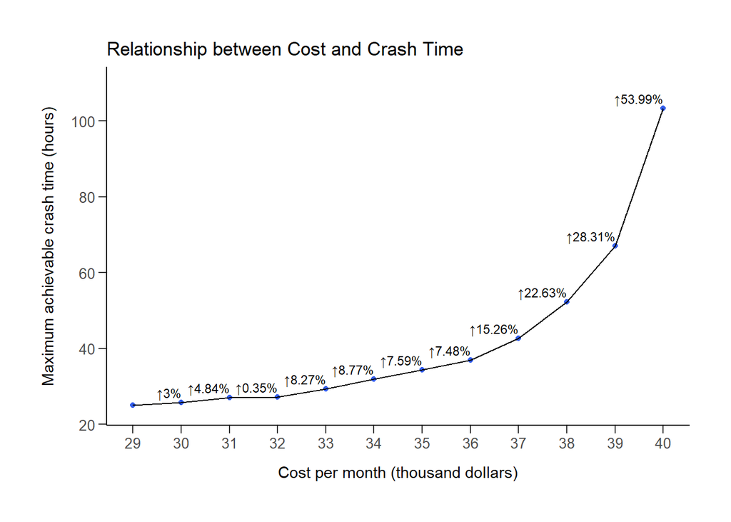

```r
ggplot(data = filtered_results_adapted, mapping = aes(x = cost, y = max_crash_time)) +
  geom_point(color = "#345eeb") +
  geom_line() +
  labs(title = "Relationship between Cost and Crash Time", x = "Cost per month (thousand dollars)", y = "Maximum achievable crash time (hours)") +
  scale_x_continuous(breaks = seq(28, 40, by = 1)) +
  ylim(24, 110) +
  geom_text(aes(label = c("", paste0(stri_unescape_unicode(gsub("\\U","\\u","\\U2191", fixed=TRUE)), c(percent_change_crash_time), "%")[-1]), vjust = -0.5, hjust = 1), size = 3) +
  theme_classic() +
  theme(
    plot.margin = unit(c(1, 1, 1, 1), "cm"),
    axis.text.x = element_text(size = 10),  # Adjust the size of x-axis labels
    axis.text.y = element_text(size = 10),  # Adjust the size of y-axis labels
    axis.ticks.x = element_line(),
    axis.ticks.length = unit(0.2, "cm"),
    axis.title.x = element_text(margin = margin(t = 10, r = 0, b = 0, l = 0)),  # Add space between graph and x label
    axis.title.y = element_text(margin = margin(t = 0, r = 10, b = 0, l = 0))   # Add space between graph and y label
  )
```

## Impact of Additional Spare Machines vs. Repairmen

Compiling all the optimum combinations in the `tradeoff` dataframe, we see that from a cost of 5k to 32k per month, the strategy is to only have 1 or at most 2 repairmen and increase the number of spares. This observation is logical given that the repair time is distributed by unif(2, 6) and the machines break down with a distribution of (5, 20). 2 to 6 hours is a considerable amount of time for a run time of less than 35 hours. When there are less spares than the number of machines, once too many machines break down and none of the previously broken machines have been repaired, the system crashes.

On the other hand, as we increase the number of spares, when there are almost as many or more initial spares than the number of machines, each machine is “backed-up” with a spare. Then, the key to the continuity if the system would lie more in being able to repair broken machines as quickly as possible to sustain the pipeline of spares. At or above $32k, we see a sudden change in strategy of hiring more repairmen at the expense of having less initial spares, even though we cannot have too little spares as well.

We can thus advise the company that if they are budget strapped, they should spend the money on getting more spares, but if they have $32k budget or more for the month, this strategy will not be in their favour.

```r
tradeoff <- results %>%
  mutate(cost = num_spares*1 + num_repairmen*4) %>%
  group_by(cost) %>%
  mutate(max_crash_time = max(mean_crash_time)) %>%
  ungroup() %>%
  filter(mean_crash_time == max_crash_time) %>%
  arrange(cost) %>%
  select(-mean_crash_time)

datatable(tradeoff, options = list(pageLength = 10))
```

|  | num_spares | num_repairmen | cost | max_crash_time |
| --- | --- | --- | --- | --- |
| 1 | 1 | 1 | 5 | 7.071773535455577 |
| 2 | 2 | 1 | 6 | 7.61383028246928 |
| 3 | 3 | 1 | 7 | 8.0425329960417 |
| 4 | 4 | 1 | 8 | 9.596124850213528 |
| 5 | 5 | 1 | 9 | 10.29217644908931 |
| 6 | 6 | 1 | 10 | 11.02879626839422 |
| 7 | 7 | 1 | 11 | 12.39251266734209 |
| 8 | 8 | 1 | 12 | 13.23732469941024 |
| 9 | 9 | 1 | 13 | 12.95623023388907 |
| 10 | 10 | 1 | 14 | 14.07550111669116 |

[output cut: 26 more lines]

# Suggested Improvements to Simulation Model

1. During the optimisation part of this project (Question 3), each combination was only replicated 10 times to save on computing power. 10 samples may not might not representatively capture the true mean crash time and more replications should be run.
2. The most fundamental way of improving the simulation is to use realistic distributions where the distributions of the machine functioning and repair times are representative of the real-world. Ideally, the distributions should be determined from the analysis of historical data or expert knowledge. Especially for machining functioning time, it is unlikely that the distribution is uniform as the machine degrades over time and is more likely to break down as the time goes on. In fact, other studies have found that the failure rate of machines tend to follow an exponential distribution (Jia, Wang & Jia, 1995).
3. On a similar note, after repairing a machine, it is quite expected that the machine is already degraded to some extent and when it is put in operation again, it will break down more quickly. Taking this into consideration could further improve the realism of the distribution of machining functioning time.It may also take longer to repair the next time it breaks down.
4. In this simulation, the maintenance strategy adopted was corrective maintenance (i.e. repairing the machine only after it has failed). However, other maintenance strategies can also be considered such as preventive maintenance schedules or predictive maintenance based on the real-time condition (Németh et al., 2020). We can compare the performance of the different maintenance approaches and identify the most effective combination to balance system reliability and cost.
5. To make the scenario more representative of real-life, transportation time can be modelled since the broken machines need to be transported to the repair centre and spares need to be transported to the factory. This also means additional resources like transportation van can also be modelled in with a different capacity and number of vans, and different policies can be implemented to determine how many broken machines or spares should be transported at one time and if there is only one spare available and another on the way, whether the van should wait for the next spare to be ready to transport it.

# **References**

Jia, Y., Wang, M., & Jia, Z. (1995). Probability distribution of machining center failures. Reliability Engineering & System Safety, 50(1), 121–125. https://doi.org/10.1016/0951-8320(95)00070-I

Németh, I., Kocsis, Á., Takács, D., Shaheen, B. W., Takács, M., Merlo, A., Eytan, A., Bidoggia, L., & Olocco, P. (2020). Maintenance schedule optimisation for manufacturing systems. 4th IFAC Workshop on Advanced Maintenance Engineering, Services and Technologies - AMEST 2020, 53(3), 319–324. https://doi.org/10.1016/j.ifacol.2020.11.051